# Homework I: Life Tables

Cours: Analyse de Données M1 Mathématiques/M1 Mathématiques-Informatique

Julian Lechuga and Alexander Morakhovski

# 1 Objectives

This notebook aims at

- working with **tables** (`data.frames`, `tibbles`, `data.tables`, …) using `dplyr` or any other query language (as provided for example by `data.table`)
- visualizing demographic data as provided by [Human Mortality Database organization](https://www.mortality.org).# Life dataLife data tables can be downloaded from https://www.mortality.org. Some data have been downloaded for you and are available here.

See also https://www.lifetable.de.

If you install and load package https://cran.r-project.org/web/packages/demography/index.html, you will also find life data tables.

```r
pacman::p_load(tidyverse)
pacman::p_load(tidymodels)
library(dplyr)
library(viridis)
```

## 1.1 Life table inspection

Load the data corresponding to the country you are supposed to work on.You may use `readr::read_delim()` with appropriate options.

For country denoted by country code `xxx`, you will load three life tables:

- `xxx.fltper_1x1.txt` where `f` stands for *female*
- `xxx.mltper_1x1.txt` where `m` stands for *male*
- `xxx.bltper_1x1.txt` where `b` stands for *both*

Name the data.frames `data_f`, `data_m`, `data_b`.

```r
country_code <- list(fr='FRACNP',
                     be='BEL',
                     gb='GBRTENW',
                     nl='NLD',
                     it='ITA',
                     swe='SWE',
                     sp='ESP',
                     us='USA')

country <- 'fr'

ww_I <- 1913:1921
#ww_I <- 1938:1946 # (US)
```

```r
# TODO
file_path <- sprintf("LIFE_TABLES/%s", country_code[country][1])
data_f <- readr::read_delim(paste(file_path,".fltper_1x1.txt",sep=""), delim = " ", skip=2)
data_m <- readr::read_delim(paste(file_path,".mltper_1x1.txt",sep=""), delim = " ", skip =2)
data_b <- readr::read_delim(paste(file_path,".bltper_1x1.txt",sep=""), delim = " ", skip=2)
data_f
```

| Year | Age | mx | qx | ax | lx | dx | Lx | Tx | ex |
| --- | --- | --- | --- | --- | --- | --- | --- | --- | --- |
| 1816 | 0 | 0.18699 | 0.16573 | 0.31 | 100000 | 16573 | 88633 | 4111543 | 41.12 |
| 1816 | 1 | 0.04670 | 0.04564 | 0.50 | 83427 | 3807 | 81523 | 4022910 | 48.22 |
| 1816 | 2 | 0.03393 | 0.03336 | 0.50 | 79620 | 2656 | 78291 | 3941387 | 49.50 |
| 1816 | 3 | 0.02291 | 0.02265 | 0.50 | 76963 | 1743 | 76092 | 3863095 | 50.19 |
| 1816 | 4 | 0.01599 | 0.01587 | 0.50 | 75220 | 1194 | 74623 | 3787003 | 50.35 |
| 1816 | 5 | 0.01383 | 0.01374 | 0.50 | 74026 | 1017 | 73518 | 3712380 | 50.15 |
| 1816 | 6 | 0.01210 | 0.01203 | 0.50 | 73009 | 878 | 72570 | 3638862 | 49.84 |
| 1816 | 7 | 0.01043 | 0.01038 | 0.50 | 72131 | 748 | 71757 | 3566292 | 49.44 |
| 1816 | 8 | 0.00891 | 0.00887 | 0.50 | 71383 | 633 | 71066 | 3494535 | 48.95 |
| 1816 | 9 | 0.00760 | 0.00757 | 0.50 | 70750 | 535 | 70482 | 3423469 | 48.39 |

[output cut: 990 more lines]

```r
#data_m
#data_b
glimpse(data_f)
```

```
Observations: 22,422
Variables: 10
$ `  Year`       <chr> "  1816", "  1816", "  1816", "  1816", "  1816", "  1816", "  1816", "  1816", "  1816", "  1816", "  1816", …
$ `         Age` <chr> "          0", "          1", "          2", "          3", "          4", "          5", "          6", "    …
$ `        mx`   <chr> "     0.18699", "     0.04670", "     0.03393", "     0.02291", "     0.01599", "     0.01383", "     0.01210"…
$ `      qx`     <chr> " 0.16573", " 0.04564", " 0.03336", " 0.02265", " 0.01587", " 0.01374", " 0.01203", " 0.01038", " 0.00887", " …
$ `   ax`        <chr> " 0.31", " 0.50", " 0.50", " 0.50", " 0.50", " 0.50", " 0.50", " 0.50", " 0.50", " 0.50", " 0.50", " 0.50", " …
$ `     lx`      <chr> " 100000", "  83427", "  79620", "  76963", "  75220", "  74026", "  73009", "  72131", "  71383", "  70750", …
$ `     dx`      <chr> "  16573", "   3807", "   2656", "   1743", "   1194", "   1017", "    878", "    748", "    633", "    535", …
$ `     Lx`      <chr> "  88633", "  81523", "  78291", "  76092", "  74623", "  73518", "  72570", "  71757", "  71066", "  70482", …
$ `      Tx`     <chr> " 4111543", " 4022910", " 3941387", " 3863095", " 3787003", " 3712380", " 3638862", " 3566292", " 3494535", " …
$ `    ex`       <chr> " 41.12", " 48.22", " 49.50", " 50.19", " 50.35", " 50.15", " 49.84", " 49.44", " 48.95", " 48.39", " 47.75", …
```

For each life table, each row is identified by `Year` and `Age`. Read the documentation and concisely explain the meaning of columns

Check on http://www.mortality.org the meaning of the different columns:

**`mx`**

TODO: The number of deaths during the year divided by the average number alive during the year `qx`

TODO: The number of deaths during the year divided by the number alive at the beginning of the year.

**`ax`**

TODO: Average length of survival between ages x and x+1 for persons dying in the interval

**`lx`**

TODO: The number of persons surviving to exact age x

**`dx`**

TODO: Number of deaths between ages x and x+1

**`ex`:**

TODO: Life expectancy at exact age x (in years)

- What is the class of `data_b, ...`?
- Inspect `data_f` using `glimpse`.

```r
# TODO:
class(data_b)
```

```
[1] "spec_tbl_df" "tbl_df"      "tbl"         "data.frame"
```

```r
glimpse(data_f)
```

```
Observations: 22,422
Variables: 10
$ `  Year`       <chr> "  1816", "  1816", "  1816", "  1816", "  1816", "  1816", "  1816", "  1816", "  1816", "  1816", "  1816", …
$ `         Age` <chr> "          0", "          1", "          2", "          3", "          4", "          5", "          6", "    …
$ `        mx`   <chr> "     0.18699", "     0.04670", "     0.03393", "     0.02291", "     0.01599", "     0.01383", "     0.01210"…
$ `      qx`     <chr> " 0.16573", " 0.04564", " 0.03336", " 0.02265", " 0.01587", " 0.01374", " 0.01203", " 0.01038", " 0.00887", " …
$ `   ax`        <chr> " 0.31", " 0.50", " 0.50", " 0.50", " 0.50", " 0.50", " 0.50", " 0.50", " 0.50", " 0.50", " 0.50", " 0.50", " …
$ `     lx`      <chr> " 100000", "  83427", "  79620", "  76963", "  75220", "  74026", "  73009", "  72131", "  71383", "  70750", …
$ `     dx`      <chr> "  16573", "   3807", "   2656", "   1743", "   1194", "   1017", "    878", "    748", "    633", "    535", …
$ `     Lx`      <chr> "  88633", "  81523", "  78291", "  76092", "  74623", "  73518", "  72570", "  71757", "  71066", "  70482", …
$ `      Tx`     <chr> " 4111543", " 4022910", " 3941387", " 3863095", " 3787003", " 3712380", " 3638862", " 3566292", " 3494535", " …
$ `    ex`       <chr> " 41.12", " 48.22", " 49.50", " 50.19", " 50.35", " 50.15", " 49.84", " 49.44", " 48.95", " 48.39", " 47.75", …
```

**Which columns needs retyping?**

## 1.2 Life table cleaning

Remove white spaces from column names. You may find useful functions in package `stringr`. Try to follow the **DRY** principle (Don’t Repeat Yourself). You need to perform the same operation on every column name.

You may use fonctional programming (using `purrr::` or `plyr::`) to process all column names of `data_xxx` using one expression. Some verbs in `dplyr::` provide you with shortcuts.Write a function `retype` that can tidy data.frames with the same schema as `data_xxx` (cleaning column names if necessary, casting some columns to `numeric`, others to `double`).

```r
retype <- function(data){
  #String cleaning
  names(data)<-str_trim(names(data))
  data$Age<-str_trim(data$Age)
  data<-data%>%
    dplyr::mutate(Year=as.numeric(Year),
                  Age=forcats::as_factor(Age),
                  mx=as.double(mx),
                  qx=as.double(qx),
                  ax=as.double(ax),
                  lx=as.numeric(lx),
                  dx=as.numeric(dx),
                  Lx=as.numeric(Lx),
                  Tx=as.numeric(Tx),
                  ex=as.double(ex))
  data
}
```

Useful tools:

- `dplyr::mutate_at`
- `dplyr::rename`
- `dplyr::rename`Apply function `retype` to the three data.frames.

```r
# TODO:
data_f<-retype(data_f)
data_m<-retype(data_m)
data_b<-retype(data_b)
head(data_f)
```

| Year | Age | mx | qx | ax | lx | dx | Lx | Tx | ex |
| --- | --- | --- | --- | --- | --- | --- | --- | --- | --- |
| 1816 | 0 | 0.18699 | 0.16573 | 0.31 | 100000 | 16573 | 88633 | 4111543 | 41.12 |
| 1816 | 1 | 0.04670 | 0.04564 | 0.50 | 83427 | 3807 | 81523 | 4022910 | 48.22 |
| 1816 | 2 | 0.03393 | 0.03336 | 0.50 | 79620 | 2656 | 78291 | 3941387 | 49.50 |
| 1816 | 3 | 0.02291 | 0.02265 | 0.50 | 76963 | 1743 | 76092 | 3863095 | 50.19 |
| 1816 | 4 | 0.01599 | 0.01587 | 0.50 | 75220 | 1194 | 74623 | 3787003 | 50.35 |
| 1816 | 5 | 0.01383 | 0.01374 | 0.50 | 74026 | 1017 | 73518 | 3712380 | 50.15 |

```r
head(data_m)
```

| Year | Age | mx | qx | ax | lx | dx | Lx | Tx | ex |
| --- | --- | --- | --- | --- | --- | --- | --- | --- | --- |
| 1816 | 0 | 0.22293 | 0.19281 | 0.3 | 100000 | 19281 | 86487 | 3908205 | 39.08 |
| 1816 | 1 | 0.04667 | 0.04561 | 0.5 | 80719 | 3681 | 78879 | 3821718 | 47.35 |
| 1816 | 2 | 0.03431 | 0.03373 | 0.5 | 77038 | 2598 | 75739 | 3742839 | 48.58 |
| 1816 | 3 | 0.02315 | 0.02289 | 0.5 | 74440 | 1704 | 73588 | 3667100 | 49.26 |
| 1816 | 4 | 0.01607 | 0.01595 | 0.5 | 72736 | 1160 | 72156 | 3593513 | 49.40 |
| 1816 | 5 | 0.01364 | 0.01354 | 0.5 | 71576 | 969 | 71091 | 3521357 | 49.20 |

```r
head(data_b)
```

| Year | Age | mx | qx | ax | lx | dx | Lx | Tx | ex |
| --- | --- | --- | --- | --- | --- | --- | --- | --- | --- |
| 1816 | 0 | 0.20534 | 0.17972 | 0.31 | 100000 | 17972 | 87524 | 4009912 | 40.10 |
| 1816 | 1 | 0.04669 | 0.04562 | 0.50 | 82028 | 3742 | 80156 | 3922388 | 47.82 |
| 1816 | 2 | 0.03412 | 0.03355 | 0.50 | 78285 | 2626 | 76972 | 3842232 | 49.08 |
| 1816 | 3 | 0.02304 | 0.02277 | 0.50 | 75659 | 1723 | 74798 | 3765260 | 49.77 |
| 1816 | 4 | 0.01604 | 0.01591 | 0.50 | 73936 | 1176 | 73348 | 3690462 | 49.91 |
| 1816 | 5 | 0.01373 | 0.01364 | 0.50 | 72760 | 992 | 72264 | 3617114 | 49.71 |

```r
glimpse(data_f)
```

```
Observations: 22,422
Variables: 10
$ Year <dbl> 1816, 1816, 1816, 1816, 1816, 1816, 1816, 1816, 1816, 1816, 1816, 1816, 1816, 1816, 1816, 1816, 1816, 1816, 1816, 1816, …
$ Age  <fct> 0, 1, 2, 3, 4, 5, 6, 7, 8, 9, 10, 11, 12, 13, 14, 15, 16, 17, 18, 19, 20, 21, 22, 23, 24, 25, 26, 27, 28, 29, 30, 31, 32…
$ mx   <dbl> 0.18699, 0.04670, 0.03393, 0.02291, 0.01599, 0.01383, 0.01210, 0.01043, 0.00891, 0.00760, 0.00629, 0.00537, 0.00491, 0.0…
$ qx   <dbl> 0.16573, 0.04564, 0.03336, 0.02265, 0.01587, 0.01374, 0.01203, 0.01038, 0.00887, 0.00757, 0.00627, 0.00536, 0.00489, 0.0…
$ ax   <dbl> 0.31, 0.50, 0.50, 0.50, 0.50, 0.50, 0.50, 0.50, 0.50, 0.50, 0.50, 0.50, 0.50, 0.50, 0.50, 0.50, 0.50, 0.50, 0.50, 0.50, …
$ lx   <dbl> 100000, 83427, 79620, 76963, 75220, 74026, 73009, 72131, 71383, 70750, 70214, 69774, 69400, 69061, 68727, 68370, 67977, …
$ dx   <dbl> 16573, 3807, 2656, 1743, 1194, 1017, 878, 748, 633, 535, 440, 374, 340, 334, 357, 393, 427, 463, 494, 518, 503, 492, 513…
$ Lx   <dbl> 88633, 81523, 78291, 76092, 74623, 73518, 72570, 71757, 71066, 70482, 69994, 69587, 69231, 68894, 68548, 68173, 67763, 6…
$ Tx   <dbl> 4111543, 4022910, 3941387, 3863095, 3787003, 3712380, 3638862, 3566292, 3494535, 3423469, 3352987, 3282993, 3213406, 314…
$ ex   <dbl> 41.12, 48.22, 49.50, 50.19, 50.35, 50.15, 49.84, 49.44, 48.95, 48.39, 47.75, 47.05, 46.30, 45.53, 44.75, 43.98, 43.23, 4…
```

# 2 Hazard rates, mortality quotients

Plot mortality quotients (column `mx`) for women as a function of `Age` for years `1913` up to `1921`. Use aesthetics to distinguish years. You will need to categorize the `Year` column (`forcats::` may be helpful).

Pay attention to axes labels, to legends. Assess logarithmic scales.

```r
# TODO:
glimpse(data_f)
```

```
Observations: 22,422
Variables: 10
$ Year <dbl> 1816, 1816, 1816, 1816, 1816, 1816, 1816, 1816, 1816, 1816, 1816, 1816, 1816, 1816, 1816, 1816, 1816, 1816, 1816, 1816, …
$ Age  <fct> 0, 1, 2, 3, 4, 5, 6, 7, 8, 9, 10, 11, 12, 13, 14, 15, 16, 17, 18, 19, 20, 21, 22, 23, 24, 25, 26, 27, 28, 29, 30, 31, 32…
$ mx   <dbl> 0.18699, 0.04670, 0.03393, 0.02291, 0.01599, 0.01383, 0.01210, 0.01043, 0.00891, 0.00760, 0.00629, 0.00537, 0.00491, 0.0…
$ qx   <dbl> 0.16573, 0.04564, 0.03336, 0.02265, 0.01587, 0.01374, 0.01203, 0.01038, 0.00887, 0.00757, 0.00627, 0.00536, 0.00489, 0.0…
$ ax   <dbl> 0.31, 0.50, 0.50, 0.50, 0.50, 0.50, 0.50, 0.50, 0.50, 0.50, 0.50, 0.50, 0.50, 0.50, 0.50, 0.50, 0.50, 0.50, 0.50, 0.50, …
$ lx   <dbl> 100000, 83427, 79620, 76963, 75220, 74026, 73009, 72131, 71383, 70750, 70214, 69774, 69400, 69061, 68727, 68370, 67977, …
$ dx   <dbl> 16573, 3807, 2656, 1743, 1194, 1017, 878, 748, 633, 535, 440, 374, 340, 334, 357, 393, 427, 463, 494, 518, 503, 492, 513…
$ Lx   <dbl> 88633, 81523, 78291, 76092, 74623, 73518, 72570, 71757, 71066, 70482, 69994, 69587, 69231, 68894, 68548, 68173, 67763, 6…
$ Tx   <dbl> 4111543, 4022910, 3941387, 3863095, 3787003, 3712380, 3638862, 3566292, 3494535, 3423469, 3352987, 3282993, 3213406, 314…
$ ex   <dbl> 41.12, 48.22, 49.50, 50.19, 50.35, 50.15, 49.84, 49.44, 48.95, 48.39, 47.75, 47.05, 46.30, 45.53, 44.75, 43.98, 43.23, 4…
```

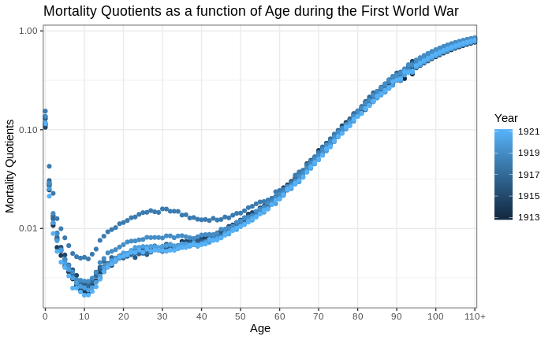

```r
data_f %>%
dplyr::filter(Year %in% ww_I) %>%
ggplot(mapping= aes(colour = Year,x=Age,y=mx)) +
geom_point()+ xlab("Age")+ ylab("Mortality Quotients") +ggtitle(paste("Mortality Quotients as a function of Age during the First World War"))+scale_x_discrete(breaks=data_f$Age[seq(1,111,by=10)]) + scale_y_log10()+theme_bw()
```

Plot mortality quotients (column `mx`) for men as a function of `Age` for years `1913` up to `1921`.

Note that you may tweak the `ggplot` object you just created and feed it with new data using `%+%` from `ggplot`.

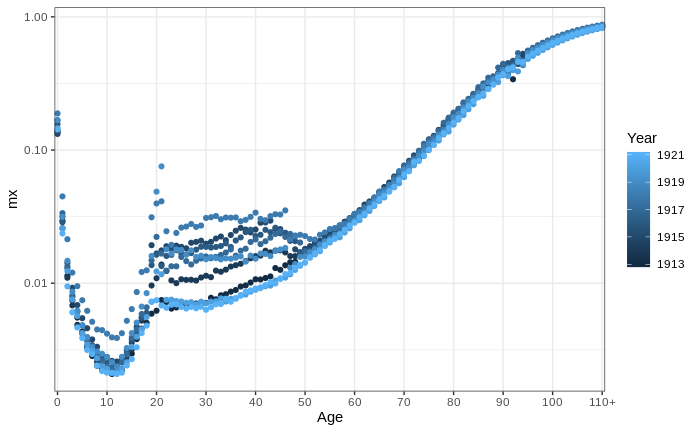

```r
# TODO:
dplyr::filter(data_m, Year %in% ww_I) -> sub_sample
ggplot(sub_sample, mapping= aes(colour = Year,x=Age,y=mx)) +
geom_point()+ scale_x_discrete(breaks=data_m$Age[seq(1,111,by=10)])+ scale_y_log10()+theme_bw()
```

## 2.1 Facetting

Build a data.frame called `big_data`, where rows are identified by `Year, Age, Sex` and comes either from `data_f` or `data_m`. Column `Sex` should be a `factor` with two levels called `Male` and `Female`.

You may proceed as follows:- Add a character column “Sex” to `data_f` and `data_m`.

- Stack the two data.frames (using `rbind`) into data.frame named `big_data`.
- Cast column `Sex` as a factor.

```r
# TODO:
data_f$Sex='Female'
data_m$Sex='Male'
data_f$Sex <- as.factor(data_f$Sex)
data_m$Sex <- as.factor(data_m$Sex)

big_data<-rbind(data_f, data_m)
glimpse(big_data)
```

```
Observations: 44,844
Variables: 11
$ Year <dbl> 1816, 1816, 1816, 1816, 1816, 1816, 1816, 1816, 1816, 1816, 1816, 1816, 1816, 1816, 1816, 1816, 1816, 1816, 1816, 1816, …
$ Age  <fct> 0, 1, 2, 3, 4, 5, 6, 7, 8, 9, 10, 11, 12, 13, 14, 15, 16, 17, 18, 19, 20, 21, 22, 23, 24, 25, 26, 27, 28, 29, 30, 31, 32…
$ mx   <dbl> 0.18699, 0.04670, 0.03393, 0.02291, 0.01599, 0.01383, 0.01210, 0.01043, 0.00891, 0.00760, 0.00629, 0.00537, 0.00491, 0.0…
$ qx   <dbl> 0.16573, 0.04564, 0.03336, 0.02265, 0.01587, 0.01374, 0.01203, 0.01038, 0.00887, 0.00757, 0.00627, 0.00536, 0.00489, 0.0…
$ ax   <dbl> 0.31, 0.50, 0.50, 0.50, 0.50, 0.50, 0.50, 0.50, 0.50, 0.50, 0.50, 0.50, 0.50, 0.50, 0.50, 0.50, 0.50, 0.50, 0.50, 0.50, …
$ lx   <dbl> 100000, 83427, 79620, 76963, 75220, 74026, 73009, 72131, 71383, 70750, 70214, 69774, 69400, 69061, 68727, 68370, 67977, …
$ dx   <dbl> 16573, 3807, 2656, 1743, 1194, 1017, 878, 748, 633, 535, 440, 374, 340, 334, 357, 393, 427, 463, 494, 518, 503, 492, 513…
$ Lx   <dbl> 88633, 81523, 78291, 76092, 74623, 73518, 72570, 71757, 71066, 70482, 69994, 69587, 69231, 68894, 68548, 68173, 67763, 6…
$ Tx   <dbl> 4111543, 4022910, 3941387, 3863095, 3787003, 3712380, 3638862, 3566292, 3494535, 3423469, 3352987, 3282993, 3213406, 314…
$ ex   <dbl> 41.12, 48.22, 49.50, 50.19, 50.35, 50.15, 49.84, 49.44, 48.95, 48.39, 47.75, 47.05, 46.30, 45.53, 44.75, 43.98, 43.23, 4…
$ Sex  <fct> Female, Female, Female, Female, Female, Female, Female, Female, Female, Female, Female, Female, Female, Female, Female, …
```

Plot mortality quotients (column `mx`) as a function of `Age` for years `1913` up to `1921` facet according to `Sex`.

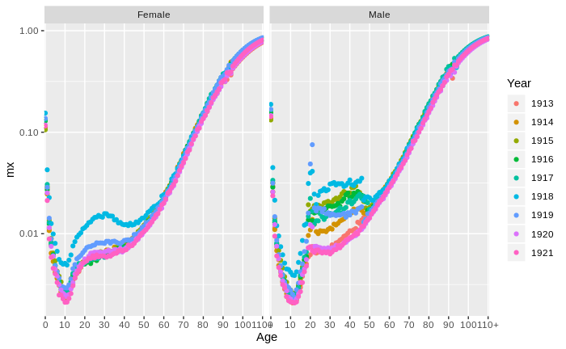

```r
# TODO:
dplyr::filter(big_data, Year %in% ww_I) -> sub_sample
sub_sample<-dplyr::mutate(sub_sample,Year=as.factor(Year))
ggplot(sub_sample, mapping= aes(colour = Year,x=Age,y=mx)) +
geom_point()+ scale_x_discrete(breaks=big_data$Age[seq(1,111,by=10)])+ scale_y_log10()+facet_wrap(~ Sex)
```

```r
summary(big_data$Age)
```

```
      0       1       2       3       4       5       6       7       8       9      10      11      12      13      14      15      16
    404     404     404     404     404     404     404     404     404     404     404     404     404     404     404     404     404
     17      18      19      20      21      22      23      24      25      26      27      28      29      30      31      32      33
    404     404     404     404     404     404     404     404     404     404     404     404     404     404     404     404     404
     34      35      36      37      38      39      40      41      42      43      44      45      46      47      48      49      50
    404     404     404     404     404     404     404     404     404     404     404     404     404     404     404     404     404
     51      52      53      54      55      56      57      58      59      60      61      62      63      64      65      66      67
    404     404     404     404     404     404     404     404     404     404     404     404     404     404     404     404     404
     68      69      70      71      72      73      74      75      76      77      78      79      80      81      82      83      84
    404     404     404     404     404     404     404     404     404     404     404     404     404     404     404     404     404
     85      86      87      88      89      90      91      92      93      94      95      96      97      98 (Other)
    404     404     404     404     404     404     404     404     404     404     404     404     404     404    4848
```

```r
levels(big_data$Age)
```

```
  [1] "0"    "1"    "2"    "3"    "4"    "5"    "6"    "7"    "8"    "9"    "10"   "11"   "12"   "13"   "14"   "15"   "16"   "17"
 [19] "18"   "19"   "20"   "21"   "22"   "23"   "24"   "25"   "26"   "27"   "28"   "29"   "30"   "31"   "32"   "33"   "34"   "35"
 [37] "36"   "37"   "38"   "39"   "40"   "41"   "42"   "43"   "44"   "45"   "46"   "47"   "48"   "49"   "50"   "51"   "52"   "53"
 [55] "54"   "55"   "56"   "57"   "58"   "59"   "60"   "61"   "62"   "63"   "64"   "65"   "66"   "67"   "68"   "69"   "70"   "71"
 [73] "72"   "73"   "74"   "75"   "76"   "77"   "78"   "79"   "80"   "81"   "82"   "83"   "84"   "85"   "86"   "87"   "88"   "89"
 [91] "90"   "91"   "92"   "93"   "94"   "95"   "96"   "97"   "98"   "99"   "100"  "101"  "102"  "103"  "104"  "105"  "106"  "107"
[109] "108"  "109"  "110+"
```

```r
nlevels(big_data$Age)
```

```
[1] 111
```

Map `Sex` to some aesthetics and facet by `Year`.

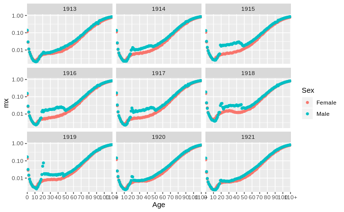

```r
# TODO:
dplyr::filter(big_data, Year %in% ww_I) -> sub_sample
sub_sample<-dplyr::mutate(sub_sample,Year=as.factor(Year))
ggplot(sub_sample, mapping= aes(colour = Sex,x=Age,y=mx)) +
geom_point()+ scale_x_discrete(breaks=sub_sample$Age[seq(1,111,by=10)])+ scale_y_log10()+facet_wrap(~ Year)
```

**List puzzling features on those plots.**

TODO: A lot of people die at around 20-30 (men especially) because of the war

TODO:# Trends## Infant mortality ratePlot mortality quotients at ages $0, 1, 5$ as a function of time. Distinguish women and men.

```r
dplyr::filter(big_data, Age %in% c(0,1,5)) -> infant
glimpse(big_data)
```

```
Observations: 44,844
Variables: 11
$ Year <dbl> 1816, 1816, 1816, 1816, 1816, 1816, 1816, 1816, 1816, 1816, 1816, 1816, 1816, 1816, 1816, 1816, 1816, 1816, 1816, 1816, …
$ Age  <fct> 0, 1, 2, 3, 4, 5, 6, 7, 8, 9, 10, 11, 12, 13, 14, 15, 16, 17, 18, 19, 20, 21, 22, 23, 24, 25, 26, 27, 28, 29, 30, 31, 32…
$ mx   <dbl> 0.18699, 0.04670, 0.03393, 0.02291, 0.01599, 0.01383, 0.01210, 0.01043, 0.00891, 0.00760, 0.00629, 0.00537, 0.00491, 0.0…
$ qx   <dbl> 0.16573, 0.04564, 0.03336, 0.02265, 0.01587, 0.01374, 0.01203, 0.01038, 0.00887, 0.00757, 0.00627, 0.00536, 0.00489, 0.0…
$ ax   <dbl> 0.31, 0.50, 0.50, 0.50, 0.50, 0.50, 0.50, 0.50, 0.50, 0.50, 0.50, 0.50, 0.50, 0.50, 0.50, 0.50, 0.50, 0.50, 0.50, 0.50, …
$ lx   <dbl> 100000, 83427, 79620, 76963, 75220, 74026, 73009, 72131, 71383, 70750, 70214, 69774, 69400, 69061, 68727, 68370, 67977, …
$ dx   <dbl> 16573, 3807, 2656, 1743, 1194, 1017, 878, 748, 633, 535, 440, 374, 340, 334, 357, 393, 427, 463, 494, 518, 503, 492, 513…
$ Lx   <dbl> 88633, 81523, 78291, 76092, 74623, 73518, 72570, 71757, 71066, 70482, 69994, 69587, 69231, 68894, 68548, 68173, 67763, 6…
$ Tx   <dbl> 4111543, 4022910, 3941387, 3863095, 3787003, 3712380, 3638862, 3566292, 3494535, 3423469, 3352987, 3282993, 3213406, 314…
$ ex   <dbl> 41.12, 48.22, 49.50, 50.19, 50.35, 50.15, 49.84, 49.44, 48.95, 48.39, 47.75, 47.05, 46.30, 45.53, 44.75, 43.98, 43.23, 4…
$ Sex  <fct> Female, Female, Female, Female, Female, Female, Female, Female, Female, Female, Female, Female, Female, Female, Female, …
```

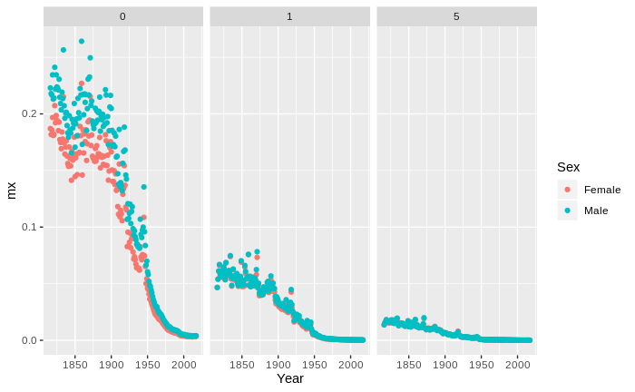

```r
p<-ggplot(mapping= aes(colour = Sex,x=Year,y=mx)) +
  geom_point() +
  facet_wrap(~ Age)
p%+%infant
```

```r
# TODO:
```

**Can you match abrupt changes and historical events?**

TODO: The spanish flu outbreak of 1918 killed a lot of people and infants.

## 2.2 As times goes byPlot mortality quotients at ages $15, 20, 40, 60$ as a function of time.

Distinguish women and men.

Note again that you may tweak the `ggplot` object you just created and feed it with new data using `%+%` from `ggplot`.

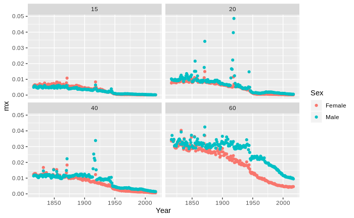

```r
ages <- c(15, 20, 40, 60)
dplyr::filter(big_data, Age %in% ages) -> infant2
p%+%infant2
```

```r
# TODO:
```

**TODO:**

List puzzling features In some years the mortality quotient increases abruptly. This is due to wars, famine and disease outbreaks. ## Mortality quotients

- Plot mortality quotient as a function of age for years $1825, 1850, 1875, \ldots, 2000$, facet with respect to `Sex`
- Compare different scales (logarithmic or linear) on the different axes

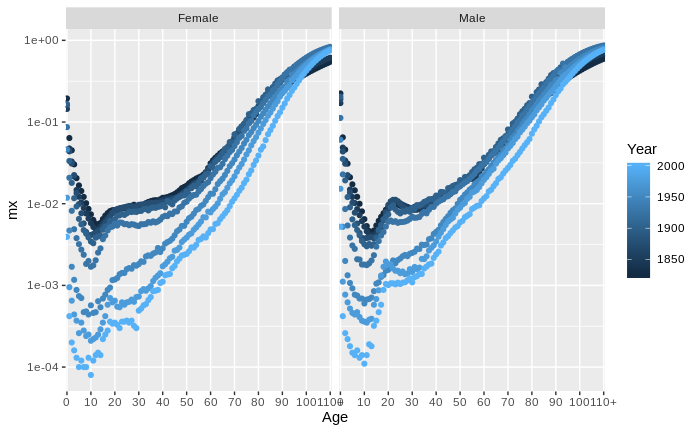

```r
years <- seq(1825, 2000, by = 25)
dplyr::filter(big_data, Year %in% years) -> mq
ggplot(mq, mapping= aes(x=Age,y=mx)) +
  geom_point(aes(colour=Year)) +scale_x_discrete(breaks=sub_sample$Age[seq(1,111,by=10)])+ scale_y_log10()+
  facet_wrap(~ Sex)
```

```r
# TODO:
```

# 3 Rearrangement

From data.frame `data_m, data_f`, extract a numerical matrix `A` where rows correspond to year (say `t`), columns to age (say `x`), and entry for year `t` and age `x` is the mortality quotient at age `x` for year `t`. Finally, we take logarithms: $A_{t,x} = \log m_{t,x}$.

You may use functions `pivot_wider`, `pivot_longer` from `tidyr::` package.

```r
# TODO
pivot<- function(data){
  data%>%
  select(Age,mx,Year) %>% tidyr::pivot_wider(names_from = Age, values_from = mx) %>%
  column_to_rownames(var = "Year") -> pivot1
  pivot1=data.matrix(pivot1)
  pivot1
  }

pivot(data_f) -> pivot1
```

> Factorizations of $A$ play a significant role in demographic modeling. More on this topic in PCA chapter.

# 4 Life expectancy

Write a function that takes as input a vector of mortality quotients, as well as an age, and returns the residual life expectancy corresponding to the vector and the given age.

```r
# TODO:
pivot1["2017",]->x

rex<- function(x,y){
  sum(cumprod(1-x[(y+1):length(x)]))
}

rex(x, 0)
```

```
[1] 84.53527
```

Write a function that takes as input a *life table* and returns a matrix $E$ where rows correspond to `Year` and columns to `Age` with $E_{t,x}$ equal to the residual life expectancy at age $x$ for year $t$.

```r
# TODO:
full_rex <- function(lt)
{
  # TODO:
  retype(lt)->lt
  pivot(lt)->pivottable
  full <- pivottable
  for (Year in 1:nrow(pivottable)){
    for(Age in 1:ncol(pivottable)){
      full[Year,Age]=rex(pivottable[Year,],Age)
    }
  }
  full


}
lt <- readr::read_delim(paste(file_path, ".fltper_1x1.txt",sep=""), delim = " ", skip=2)
```

Plot residual life expectancy as a function of `Year` at ages $60$ and $65$. You may proceed by first performing aggregation on `data_...` (grouping by `Year`), and then compute residual life expectancy at different ages by slicing the `mx` column. Recall that when mapping hazard rate to residual life expextancy, the order of multiplications matters. How could you secure your computation so that it still works if the rows of `data_...` are shuffled ?

Function `tidyr::pivot_longer` may help.

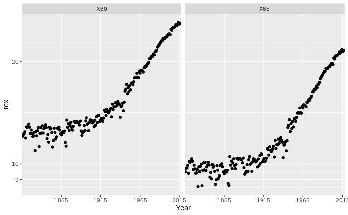

```r
# TODO:
full_rex(lt) -> a
a=a[,c(61,66)]
a=data.frame(a)
rownames_to_column(a, var ="Year") -> a
pivot_longer(a,-Year,names_to = "Age", values_to= "rex")->a

a %>% ggplot(mapping= aes(x=Year,y=rex)) +
  geom_point() +scale_x_discrete(breaks=a$Year[seq(0,length(a$Year),by=100)])+ scale_y_log10()+
  facet_wrap(~ Age)
```

# 5 References

- [Human Mortality Database](https://www.mortality.org)
- [Tables de mortalité françaises, Jacques Vallin et France Meslé](https://www.lifetable.de/data/FRA/FRA000018061997CY1.pdf)